# Chp8

OUYANG YUCHEN

2023-04-26

# Chp8 Data Import

### 8.2.4 Exercise

1. What function would you use to read a file where fields were separated with “|”?

   read_delim(delim=“|”)
2. Apart from file, skip, and comment, what other arguments do read_csv() and read_tsv() have in common?

   Check `?read_delim()`, `col_names`, `col_types`, `id`, `col_select`, `lazy`, `progress`…
3. What are the most important arguments to read_fwf()?

   The most important arg is `col_positions`, which tells the function where data columns begin  
   and end.
4. Sometimes strings in a CSV file contain commas. To prevent them from causing problems, they need to be surrounded by a quoting character, like ” or ’. By default, read_csv() assumes that the quoting character will be “. To read the following text into a data frame, what argument to read_csv() do you need to specify?

   ```r
   library(tidyverse)
   read_csv("x,y\n1,'a,b'",quote="'")
   ```

   ```
   ## # A tibble: 1 × 2
   ##       x y
   ##   <dbl> <chr>
   ## 1     1 a,b
   ```

5. Identify what is wrong with each of the following inline CSV files. What happens when you run the code?

   ```r
   # fewer col_names, should be columns
   read_csv("a,b\n1,2,3\n4,5,6")
   ```

   ```
   ## # A tibble: 2 × 2
   ##       a     b
   ##   <dbl> <dbl>
   ## 1     1    23
   ## 2     4    56
   ```

   ```r
   # the number of columns and data mismateched
   read_csv("a,b,c\n1,2\n1,2,3,4")
   ```

   ```
   ## # A tibble: 2 × 3
   ##       a     b     c
   ##   <dbl> <dbl> <dbl>
   ## 1     1     2    NA
   ## 2     1     2    34
   ```

   ```r
   # quote inconstency
   read_csv("a,b\n\"1")
   ```

   ```
   ## # A tibble: 0 × 2
   ## # … with 2 variables: a <chr>, b <chr>
   ```

   ```r
   # mixed numbers and characters
   read_csv("a,b\n1,2\na,b")
   ```

   ```
   ## # A tibble: 2 × 2
   ##   a     b
   ##   <chr> <chr>
   ## 1 1     2
   ## 2 a     b
   ```

   ```r
   #non-csv delimiter ";"
   read_csv("a;b\n1;3")
   ```

   ```
   ## # A tibble: 1 × 1
   ##   `a;b`
   ##   <chr>
   ## 1 1;3
   ```

6. Practice referring to non-syntactic names in the following data frame by:

   ```r
   annoying <- tibble(
   `1` = 1:10,
   `2` = `1` * 2 + rnorm(length(`1`))
   )
   ```

   1. Extracting the variable called `1`.

   ```r
   annoying$`1`
   ```

   ```
   ##  [1]  1  2  3  4  5  6  7  8  9 10
   ```

   2. Plotting a scatter plot of `1` vs.`2`.

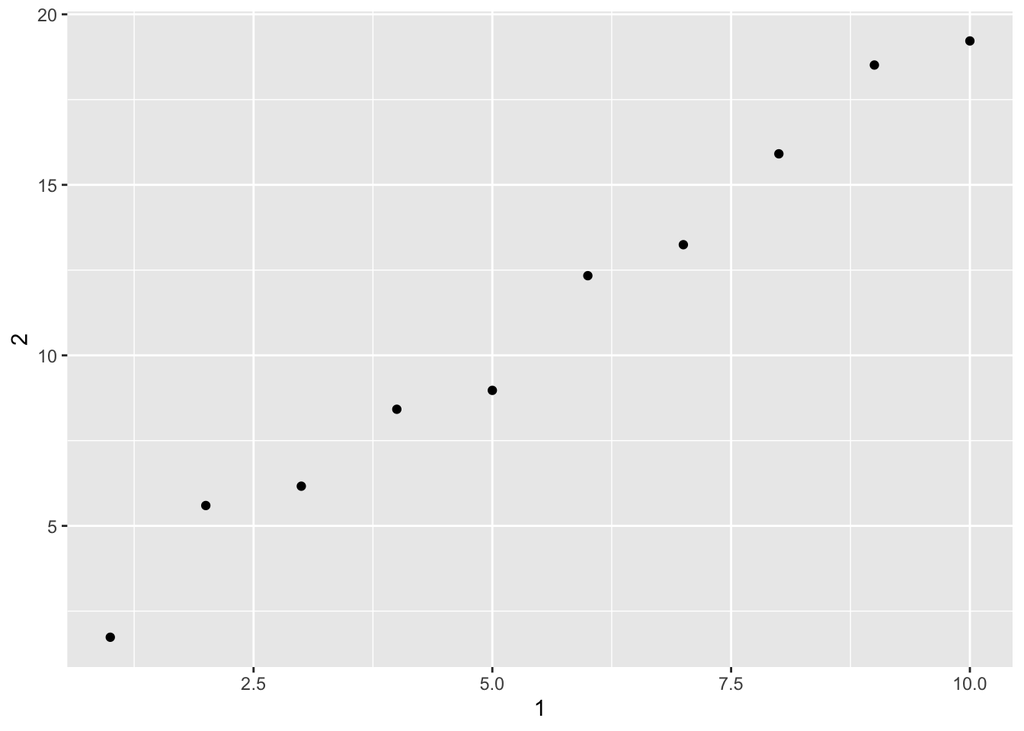

   ```r
   ggplot(annoying,aes(x=`1`,y=`2`))+geom_point()
   ```

   3. Creating a new column called `3`, which is `2` divided by `1`.

   ```r
   annoying <- annoying %>% mutate(`3` = `2`/`1`)
   ```

   4. Renaming the columns to `one`, `two`, and `three`.

   ```r
   annoying <- annoying %>% rename(
     "one" = `1`,
     "two" = `2`,
     "three" = `3`)
   ```